# A History of Pitchfork Reviews

210155327

14/05/2022

[figure not shown]

# Project Overview

Founded as an **independent music blog** in 1995, Pitchfork has since gone on to become one of most influential publishers in the music industry, reviewing **tens of thousands** of albums throughout the past **25 years.** While you can now rely on them to consistently review every new release using their infamously specific 0.0 - 10 [scoring system](https://pitchfork.com/features/lists-and-guides/25-years-of-pitchfork-reviews-by-the-numbers/), it wasn’t too long ago that Pitchfork were scrutinised for being nothing more than a pretentious independent-rock publisher created by [“middle class white guys in their 20s and 30s”](https://pitchfork.com/features/lists-and-guides/the-history-of-the-pitchfork-reviews-section-in-38-important-reviews/).

As Pitchfork has grown in stature, their [masthead](https://pitchfork.com/masthead/) has diversified, ultimately allowing them to branch out and provide in-depth reviews of albums from a wide range of genres. The **aim** of this project is to explore their vast plethora of reviews, while attempting to identify possible **trends/biases** across certain genres.

[figure not shown]

Image showing Pitchfork scrutiny - Credit:Crash Thompson

## Research Questions

Considering how much Pitchfork has evolved as a publisher over the past 25 years, I was interested to see how their approach to certain genres had altered throughout this period. This project has **2** main research questions:

1. Given their roots as an indie-rock publisher, does Pitchfork hold a bias towards **Rock** music?
2. With **Hip-Hop’s** emphatic rise to the mainstream over the past decade, has this increased popularity caused caused a decline in the number of **Rock** reviews?

## Dataset

The source of the data used in this project was taken from a **Reddit** User, under the name [u/snappcrack](https://components.one/datasets/pitchfork-reviews-dataset). This data is a revised version of an original data set published to [Kaggle](https://www.kaggle.com/datasets/nolanbconaway/pitchfork-data) by Nolan Conway in 2017. The updated version contains 2 extra years worth of data, resulting in a data set containing **every** published Pitchfork album review between **January 1999 - January 2019**. The full data set contains **20,873 data entries**.

```r
library(tidyverse)
#Import the raw data
pitchforkdata <- read.csv(here("raw_data", "pitchfork.csv"))
#Select only the columns which are relevant for the current project
pitchforkdata <- pitchforkdata %>%
  select(artist, album, genre, score, date, author, role, bnm, label, release_year)
#Let's take a look at the first 6 rows of data
```

Pitchfork Data relevant to Project

| artist | album | genre | score | date | author | role | bnm | label | release_year |
| --- | --- | --- | --- | --- | --- | --- | --- | --- | --- |
| David Byrne | “…The Best Live Show of All Time” — NME EP | Rock | 5.5 | January 11 2019 | Andy Beta | Contributor | 0 | Nonesuch | 2018 |
| DJ Healer | Lost Lovesongs / Lostsongs Vol. 2 | Electronic | 6.2 | January 11 2019 | Chal Ravens | Contributor | 0 | Planet Uterus | 2019 |
| Jorge Velez | Roman Birds | Electronic | 7.9 | January 10 2019 | Philip Sherburne | Contributing Editor | 0 | Self-released | 2019 |
| Chandra | Transportation EPs | Rock | 7.8 | January 10 2019 | Andy Beta | Contributor | 0 | Telephone Explosion | 2018 |
| The Chainsmokers | Sick Boy | Electronic | 3.1 | January 9 2019 | Larry Fitzmaurice | Contributor | 0 | Disruptor,Columbia | 2018 |
| Silent Servant | Shadows of Death and Desire | Electronic | 7.8 | January 9 2019 | Harley Brown | Contributor | 0 | Hospital Productions | 2018 |

## Codebook

The table below provides a description of each of the variables included in the data set:

| **Variable** | **Description** |
| --- | --- |
| artist | The artist who released the album |
| album | The name of the album |
| genre | The genre of which the album belongs |
| date | The date the album review was published |
| author | The name of the person who wrote the review |
| role | The author’s role at Pitchfork |
| bnm | 0 = Album not included in **Best New Music**, 1 = Album included in **Best New Music** |
| label | The record label the album was released under |
| release_year | The year the album was released |

## Visualisation 1 - Average Pitchfork Score per Genre

The first visualisation will aim to explore claims that Pitchfork hold a bias towards particular genres, namely **Rock**. In order assess these claims I will be creating a BoxPlot which reveals a direct comparison of the median scores awarded to 8 main genres between 1999 and 2018.

### Data Cleaning for Visualisation 1

```r
#Sort the original dataset so it only includes the genre and score of each album
pg1 <- pitchforkdata %>%
  select(genre, score) %>%

#Filter the data so it only contains the 'main' genres
filter(genre == "Electronic" | genre == "Experimental" | genre == "Folk/Country" | genre == "Jazz" | genre == "Metal" | genre == "Pop/R&B" | genre == "Rap" | genre == "Rock")

# Transfer this new data into a data set so it can be plotted onto a graph
pg1 <- as.data.frame(pg1)
# Observe the first 5 rows of data to see if the data is as expected
head(pg1, 5)
```

```
##        genre score
## 1       Rock   5.5
## 2 Electronic   6.2
## 3 Electronic   7.9
## 4       Rock   7.8
## 5 Electronic   3.1
```

### Plot 1 - Boxplot showing the median scores per Genre between 1999-2018

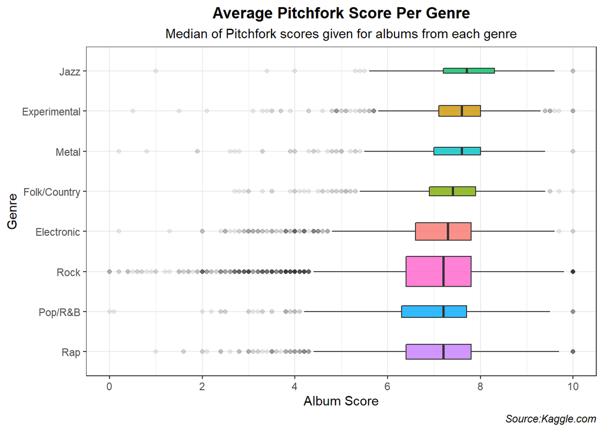

```r
#Load ggplot2
library(ggplot2)
#Plot the BoxPlot
pg1 <-  pg1 %>%
#Reorder the data so the averages are plotted from highest a to lowest
ggplot(aes(x = reorder(genre, score, na.rm = TRUE), y = score, fill = genre)) +
  geom_boxplot(
    alpha = 0.8,
    outlier.alpha = 0.1,
#Set the variable width to differentiate between the number of reviews each genre has had
    varwidth = TRUE) +
#Add labels to the graph
  labs(x = "Genre",
    y = "Album Score",
    title = "Average Pitchfork Score Per Genre",
    subtitle = "Median of Pitchfork scores given for albums from each genre",
    caption = "Source:Kaggle.com") +
#Flip the axis so that the genre names can be read more clearly
  coord_flip() +
  scale_y_continuous(limits=c(0,10), breaks = seq(0,10, by=2)) +
  theme_bw() +
  theme(plot.title = element_text(face = "bold", hjust = 0.5),
        plot.subtitle = element_text(hjust = 0.5),
        plot.caption = element_text(face = "italic"),
        legend.position = "none")

#Save this graph
ggsave(here("figures", "fig01_boxplot-mean-scores.png"))

#Display the graph below
print(pg1)
```

### Summary of Visualisation 1

Despite the general consensus, this boxplot suggests that Pitchfork doesn’t hold a bias towards **Rock** music, who’s average score is only higher than those of **Pop/R&B** and **Hip-Hop**. With all 8 main genres sitting around a median score of **7**, this BoxPlot reveals that Pitchfork are consistent with their approach to reviewing albums from each genre, and therefore are unbiased towards **Rock**.

## Visualisation 2 - Number of 10s given per Genre

Although **Visualisation 1** showed no form of bias while looking at average scores across genres, I sought to further explore these claims using an alternative approach. Although it’s an **extremely** rare occurrence, Pitchfork are occasionally prone to handing out a perfect 10 score. Although this has only occurred **129 times** as per [April 2020](https://www.distractify.com/p/pitchfork-10-albums), I wanted to observe whether there is a disparity between the number of 10s distributed across genres. In order to make this data as effective as possible, **Visualisation 2** included **sub-genres** by assigning them to their parent genre, thus allowing for a more representative overview of the data.

### Data Cleaning for Visualisation 2

```r
#Filter the data so it only shows albums given a score of 10
pg2 <- pitchforkdata %>%
  filter(score == 10) %>%
#Select the genre and score column - which is what we're interested in
  select(genre, score)
#Sort the data so the subgenres all come under their respective main genre
Rock_Tens <- sum(pg2$genre == "Rock" | pg2$genre == "Rock,Electronic")
Hip_Hop_Tens <- sum(pg2$genre == "Rap" | pg2$genre == "Rap,Rock")
Experimental_Tens <- sum(pg2$genre == "Experimental" | pg2$genre == "Experimental,Rock")
Pop_Rnb_Tens <- sum(pg2$genre == "Pop/R&B,Rock" | pg2$genre == "Pop/R&B")
Electronic_Tens <- sum(pg2$genre == "Electronic" | pg2$genre == "Electronic,Pop/R&B")
Jazz_Tens <- sum(pg2$genre == "Jazz" | pg2$genre == "Jazz,Pop/R&B")
Metal_Tens <- sum(pg2$genre == "Metal")
Folk_Country_Tens <- sum(pg2$genre == "Folk/Country")
## Place this data in a new data frame where the subgenres come under the main genre
Genre <-  c("Rock", "HipHop", "Experimental", "PopRnB", "Jazz", "Electronic", "Metal", "FolkCountry")
NumberofTens <-  c(Rock_Tens, Hip_Hop_Tens, Experimental_Tens, Pop_Rnb_Tens, Electronic_Tens, Jazz_Tens, Metal_Tens, Folk_Country_Tens)
pg2 <- data.frame(Genre, NumberofTens)
## View the last 3 rows of data
tail(pg2, 3)
```

```
##         Genre NumberofTens
## 6  Electronic            4
## 7       Metal            2
## 8 FolkCountry            1
```

### Plot 2 - Lollipop Graph showing the number of 10s scored by each Genre

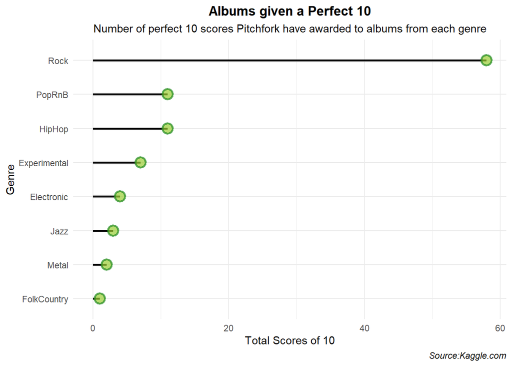

```r
pg2 <- pg2 %>%
#Reorder the data so it appears in descending order
  ggplot(aes(x = reorder(Genre, NumberofTens), y = NumberofTens)) +
  geom_segment(aes(xend = Genre, y = 0, yend = NumberofTens), lwd = 1) +
  geom_point(size = 4, color = "forestgreen", fill=alpha("yellowgreen", 0.3), alpha=0.7, shape=21, stroke=1.5) +
  theme_minimal() +
#Flip the axes of the graph so it is easier to read
  coord_flip() +
  labs(x = "Genre",
          y = "Total Scores of 10",
          title = "Albums given a Perfect 10",
          subtitle = "Number of perfect 10 scores Pitchfork have awarded to albums from each genre",
          caption = "Source:Kaggle.com") +
  theme(plot.title = element_text(face = "bold", hjust = 0.5),
        plot.subtitle = element_text(hjust = 0.5),
        plot.caption = element_text(face = "italic"),
        legend.position = "none")
#Save this graph
ggsave(here("figures", "fig02_lollipop-10-scores.png"))
#Plot the graph below
print(pg2)
```

### Summary of Visualisation 2

Where **Visualisation 1** showed there was no bias across genre average scores, the Lollipop Graph in **Visualisation 2** shows great disparities between Perfect 10 scores given to **Rock** albums in comparison with albums from all other genres. While these findings may potentially be skewed by the fact that Pitchfork has reviewed more **Rock** albums than any other genre, the sheer contrast with **all** other genres suggests Pitchfork writers certainly appear much more likely to give an album a Perfect 10 Score if it belongs to the **Rock** genre.

## Visualisation 3 - The Rise of Hip-Hop

Since the beginning of the 21st century, **Hip-Hop** has grown to become a mainstream genre, and has recently become the most streamed genre on Spotify. Given how Pitchfork started out primarily as an **Indie-Rock** publication, I wanted to see whether the rise of **Hip-Hop** could be seen through an Area Chart containing a yearly overview of the number of Pitchfork **Hip-Hop** reviews.

### Data Cleaning for Visualisations 3 & 4

In order to assess the evolution of Pitchfork **Hip-Hop** reviews, I was required to create a new dataframe which accounted for reviews coming under the many of its subgenres. Although this required a lengthy code, it provided a more representative figure.

```r
#Load in the original data once again
pitchforkdata <- read.csv(here("raw_data", "pitchfork.csv"))
#using lubridate package - sort the data into the following y-m-d
library(lubridate)
Review_Year <- mdy(pitchforkdata$date)
#Convert character data to 'Date'
Review_Year <- format(as.Date(Review_Year, format = "%Y/%m/%d"),"%Y")
#Add this new column to the original data set
pitchforkdata$Review_Year <- Review_Year
#Create a new vector for each year
Review_Year <- c("2002", "2003", "2004", "2005", "2006", "2007", "2008", "2009", "2010", "2011", "2012", "2013", "2014", "2015", "2016", "2017", "2018")
#Create a vector containing the sum of all Hip-Hop reviews for each year
HipHop <- c(sum(grepl('Rap', pitchforkdata$genre) & pitchforkdata$Review_Year == "2002"),
            sum(grepl('Rap', pitchforkdata$genre) & pitchforkdata$Review_Year == "2003"),
            sum(grepl('Rap', pitchforkdata$genre) & pitchforkdata$Review_Year == "2004"),
            sum(grepl('Rap', pitchforkdata$genre) & pitchforkdata$Review_Year == "2005"),
            sum(grepl('Rap', pitchforkdata$genre) & pitchforkdata$Review_Year == "2006"),
            sum(grepl('Rap', pitchforkdata$genre) & pitchforkdata$Review_Year == "2007"),
            sum(grepl('Rap', pitchforkdata$genre) & pitchforkdata$Review_Year == "2008"),
            sum(grepl('Rap', pitchforkdata$genre) & pitchforkdata$Review_Year == "2009"),
            sum(grepl('Rap', pitchforkdata$genre) & pitchforkdata$Review_Year == "2010"),
            sum(grepl('Rap', pitchforkdata$genre) & pitchforkdata$Review_Year == "2011"),
            sum(grepl('Rap', pitchforkdata$genre) & pitchforkdata$Review_Year == "2012"),
            sum(grepl('Rap', pitchforkdata$genre) & pitchforkdata$Review_Year == "2013"),
            sum(grepl('Rap', pitchforkdata$genre) & pitchforkdata$Review_Year == "2014"),
            sum(grepl('Rap', pitchforkdata$genre) & pitchforkdata$Review_Year == "2015"),
            sum(grepl('Rap', pitchforkdata$genre) & pitchforkdata$Review_Year == "2016"),
            sum(grepl('Rap', pitchforkdata$genre) & pitchforkdata$Review_Year == "2017"),
            sum(grepl('Rap', pitchforkdata$genre) & pitchforkdata$Review_Year == "2018"))
#Create a vector containing the sum of all Rock reviews for each year
Rock <- c(sum(grepl('Rock', pitchforkdata$genre) & pitchforkdata$Review_Year == "2002"),
          sum(grepl('Rock', pitchforkdata$genre) & pitchforkdata$Review_Year == "2003"),
          sum(grepl('Rock', pitchforkdata$genre) & pitchforkdata$Review_Year == "2004"),
          sum(grepl('Rock', pitchforkdata$genre) & pitchforkdata$Review_Year == "2005"),
          sum(grepl('Rock', pitchforkdata$genre) & pitchforkdata$Review_Year == "2006"),
          sum(grepl('Rock', pitchforkdata$genre) & pitchforkdata$Review_Year == "2007"),
          sum(grepl('Rock', pitchforkdata$genre) & pitchforkdata$Review_Year == "2008"),
          sum(grepl('Rock', pitchforkdata$genre) & pitchforkdata$Review_Year == "2009"),
          sum(grepl('Rock', pitchforkdata$genre) & pitchforkdata$Review_Year == "2010"),
          sum(grepl('Rock', pitchforkdata$genre) & pitchforkdata$Review_Year == "2011"),
          sum(grepl('Rock', pitchforkdata$genre) & pitchforkdata$Review_Year == "2012"),
          sum(grepl('Rock', pitchforkdata$genre) & pitchforkdata$Review_Year == "2013"),
          sum(grepl('Rock', pitchforkdata$genre) & pitchforkdata$Review_Year == "2014"),
          sum(grepl('Rock', pitchforkdata$genre) & pitchforkdata$Review_Year == "2015"),
          sum(grepl('Rock', pitchforkdata$genre) & pitchforkdata$Review_Year == "2016"),
          sum(grepl('Rock', pitchforkdata$genre) & pitchforkdata$Review_Year == "2017"),
          sum(grepl('Rock', pitchforkdata$genre) & pitchforkdata$Review_Year == "2018"))
#Convert this data into a new Data Frame
Number_Of_Reviews <- data.frame(row.names = Review_Year, Rock, HipHop)
#Present the first 5 rows of this new Data Set
```

Number of Hip-Hop/Rock reviews published each year

|  | Rock | HipHop |
| --- | --- | --- |
| 2002 | 488 | 54 |
| 2003 | 591 | 75 |
| 2004 | 621 | 85 |
| 2005 | 680 | 91 |
| 2006 | 695 | 71 |

### Plot 3 - Area Chart showing the evolution of Pitchfork Hip-Hop reviews

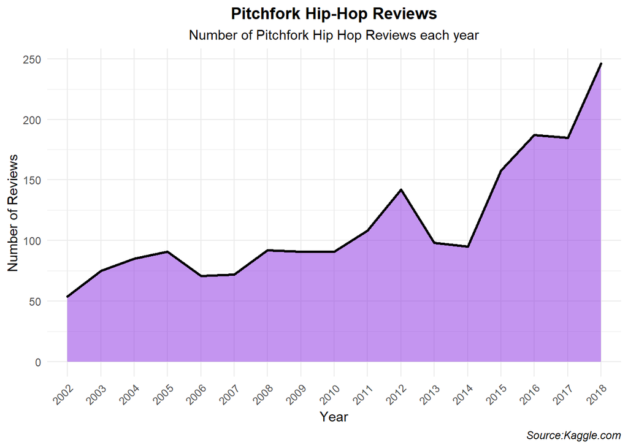

```r
#Plot an Area Chart showing the number of Hip-Hop reviews for each year
 pg3 <- Number_Of_Reviews %>%
  ggplot(aes(x = Review_Year, y = HipHop, group = 3)) +
  geom_area(fill = "blueviolet",
#Make the graph slightly transparent
            alpha = 0.5,
#Include a line to outline the graph
            colour = 1,
            lwd = 1,
            linetype = 1) +
  theme_minimal() +
#Add labels to describe the graph
  labs(
    x = "Year",
    y = "Number of Reviews",
    title = "Pitchfork Hip-Hop Reviews",
    subtitle = "Number of Pitchfork Hip Hop Reviews each year",
    caption = "Source:Kaggle.com") +
  theme(plot.title = element_text(face = "bold", hjust = 0.5),
        plot.subtitle = element_text(hjust = 0.5),
        plot.caption = element_text(face = "italic"),
#Change the angle of the X Axis labels so they're easier to read
        axis.text.x = element_text(angle = 45, hjust = 1))
#Save the graph
ggsave(here("figures", "fig03_areachart-hiphop.png"))
#Plot the graph below
print(pg3)
```

## Visualisation 4 - Hip-Hop Rise vs Rock Decline

With **Visualisation 3** revealing a dramatic increase in the number of **Hip-Hop** reviews, I was eager to see what sort of impact - if any - this had on Pitchfork’s tendency to review **Rock** albums. Using the same data set as **Visualisation 3**, I plotted a Line Graph with the aim of comparing the rise in **Hip-Hop** publications alongside those of **Rock** albums.

### Plot 4 - Line Chart comparing the number of Hip-Hop/Rock reviews

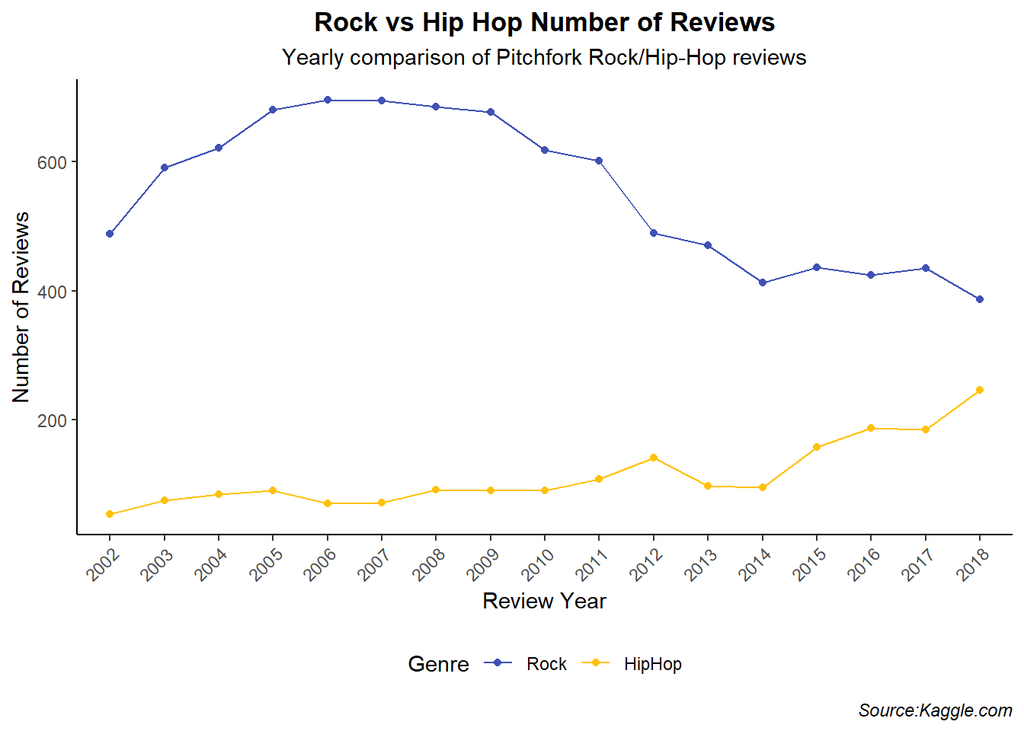

```r
pg4 <- Number_Of_Reviews %>%
  ggplot(mapping = aes(x = Review_Year)) +
#Plot the Rock data on the y axis
  geom_line(mapping = aes(y = Rock, group = 1, colour = "Rock")) +
  geom_point(mapping = aes(y = Rock, group = 1, colour = "Rock")) +
#Plot the Hip-Hop data on the y axis
  geom_line(mapping = aes(y = HipHop, group = 3, colour = "HipHop")) +
  geom_point(mapping = aes(y = HipHop, group = 3, colour = "HipHop")) +
  theme_classic() +
#Add labels to the graph
  labs(
    x = "Review Year",
    y = "Number of Reviews",
    title = "Rock vs Hip Hop Number of Reviews",
    subtitle = "Yearly comparison of Pitchfork Rock/Hip-Hop reviews",
    caption = "Source:Kaggle.com") +
#Change the colours of the Y axis variables
  scale_colour_manual(values = c("Rock"="#3F51B5", "HipHop"="#FFC107")) +
#Change the position and name of the legend
  theme(legend.position = "bottom") +
  labs(col = "Genre") +
  theme(plot.title = element_text(face = "bold", hjust = 0.5),
        plot.subtitle = element_text(hjust = 0.5),
        plot.caption = element_text(face = "italic"),
        axis.text.x = element_text(angle = 45, hjust = 1))
#Save the graph
ggsave(here("figures", "fig04_linechart-rock-vs-hiphop.png"))
#Plot the graph below
print(pg4)
```

### Summary of Visualisation 4

This Line Graph directly plots a yearly comparison of the number of **Hip-Hop** & **Rock** reviews between **2002 - 2018**. While there was initially an astronomical contrast between the number of published reviews, since 2006 there has been a clear, gradual rise in the number of Pitchfork’s **Hip-Hop** reviews. Coinciding with this, the graph illustrates a dramatic decrease in the number of **Rock** reviews between 2009-2018. Despite the number of **Rock** reviews still exceeding those of **Hip-Hop** by 2018, the development of this graph suggests as **Hip-Hop** continues to grow in popularity, Pitchfork are beginning to deviate from their primary roots as a **Rock** publisher.

## Limitations & Future Directions

While I do feel this project has successfully illustrated some of Pitchfork’s trends when it comes to album reviews, I also recognise certain limitations within the study. Firstly, while **Visualisation 1** appears to reveal a similar average score across genres, these findings may have been swayed by the omission of subgenres. Though I wanted to keep the data simple, I recognise how many Pitchfork albums are classified as a ‘subgenre’, and therefore failing to include these may have had a significant impact on the data. Additionally, although the boxplot revealed the proportion of the reviews for each genre, I failed to take this into consideration when observing the number of 10s given across genres. Alternatively, I could have assessed the data in a way which calculated the percentage of each genre’s reviews which had received a 10, thus providing a more insightful overview of potential biases across genres.

If I was to analyse this data again in the future, I would divert my attention to the Best New Music column. While I failed to address this during the current project, I feel as though comparing the amount of featured albums each genre has in the Best New Music column would provide an alternative approach to measuring potential bias across genres.

The full repo for this project is available here: https://github.com/meicalowen/PSY6422-Data-Visualisation